# Homework 1

### Preliminaries

- Verify this file (`hw01.Rmd`) is in the directory `COURSE/homework/hw1/`.
- Download `lake-monona-winters-2021.csv` and place them in your course `data` folder.
- Set the working directory to the same location.
- Edit this file, answer the questions, knit, and submit your solutions to Canvas.

### The purpose of this assignment is to:

- practice with some fundamentals of base R, including vectors
- create a ggplot
- Read ggplot2 code examples for making graphics and describe what different commands do
- Practice using `ggplot2` commands on new data to mimic examples from lecture

## Problems

### 1

Use R to sum up the numbers from 4 to 72 by:

- creating a vector with these numbers
- using the base R function `sum()` to calculate their sum.

```r
## Type your code here
x <- c(4:72)
x
```

```
##  [1]  4  5  6  7  8  9 10 11 12 13 14 15 16 17 18 19 20 21 22 23 24 25 26 27 28
## [26] 29 30 31 32 33 34 35 36 37 38 39 40 41 42 43 44 45 46 47 48 49 50 51 52 53
## [51] 54 55 56 57 58 59 60 61 62 63 64 65 66 67 68 69 70 71 72
```

```r
sum(x)
```

```
## [1] 2622
```

The sum of the integers is: 2622

### 2

The following R chunk will set a random seed and then create a vector of random numbers. By setting the random seed, each person’s vector will be identical as all will use the same stream of computer-generated random numbers.

```r
set.seed(20220623)
v2 = runif(10)
v2
```

```
##  [1] 0.6694091 0.1837035 0.2976436 0.7245256 0.3675412 0.4002747 0.7743203
##  [8] 0.7720406 0.8900038 0.3464703
```

Create a vector named `v2_a` from `v2` by dividing each value by the sum of these ten values. *Note: this re-weighting results in a new vector where the values are proportional to the originals, but sum to one.*

```r
## Type your code here
z <- sum(v2)
z
```

```
## [1] 5.425933
```

```r
v2_a <- v2/z
v2_a
```

```
##  [1] 0.12337218 0.03385658 0.05485576 0.13353015 0.06773788 0.07377067
##  [7] 0.14270731 0.14228716 0.16402780 0.06385451
```

```r
sum(v2_a)
```

```
## [1] 1
```

```r
sd(v2_a)
```

```
## [1] 0.0457414
```

#### 2A

What is the second element of `v2_a`?

0.03385658

#### 2B

What is the minimum value of `v2_a`?

0.03385658

#### 2C

What is the standard deviation of `v2_a`? Use the function `sd()`. (The standard deviation is a numerical summary of a sample of numbers that measures the size of the spread around their mean.)

0.0457414

### 3

This block of code reads in the Lake Mendota winter freeze data.

```r
mendota = read_csv("../../data/lake-mendota-winters-2021.csv")
```

#### 3A

Create a vector named `y` which is the duration of total days that Lake Mendota is closed by ice for each winter in the data set.

Calculate the mean of these values.

```r
## Type your code here
y <- mendota$duration
y
```

```
##   [1] 118 151 121  96 110 117 132 104 125 118 125 123 110 127 131  99 126 144
##  [19] 136 126  91 130  62 112  99 161  78 124 119 124 128 131 113  88  75 111
##  [37]  97 112 101 101  91 110 100 130 111 107 105  89 126 108  97  94  83 106
##  [55]  98 101 108  99  88 115 102 116 115  82 110  81  96 125 104 105 124 103
##  [73] 106  96 107  98  65 115  91  94 101 121 105  97 105  96  82 116 114  92
##  [91]  98 101 104  96 109 122 114  81  85  92 114 111  95 126 105 108 117 112
## [109] 113 120  65  98  91 108 113 110 105  97 105 107  88 115 123 118  99  93
## [127]  96  54 111  85 107  89  87  97  93  88  99 108  94  74 119 102  47  81
## [145]  53 115  21  89  80 101  95  66 106  97  87 109  57  87 117  91  62  65
## [163]  94  86  70  77
```

```r
m = mean(y)
m
```

```
## [1] 102.0482
```

What is the mean? 102.0482

#### 3B

Read this [short page of notes](https://bookdown.org/rdpeng/rprogdatascience/vectorized-operations.html) on vectorized operations in R.

Create a vector named `r` by taking `y` and subtracting from each value the mean you computed in the previous part (Make sure to use vectorized operations! If you have to use a for loop here, you’re doing it wrong. In R, vectorized operations are usually orders of magnitude faster than loops.)

```r
## Type your code here
r <- y - m
r
```

```
##   [1]  15.95180723  48.95180723  18.95180723  -6.04819277   7.95180723
##   [6]  14.95180723  29.95180723   1.95180723  22.95180723  15.95180723
##  [11]  22.95180723  20.95180723   7.95180723  24.95180723  28.95180723
##  [16]  -3.04819277  23.95180723  41.95180723  33.95180723  23.95180723
##  [21] -11.04819277  27.95180723 -40.04819277   9.95180723  -3.04819277
##  [26]  58.95180723 -24.04819277  21.95180723  16.95180723  21.95180723
##  [31]  25.95180723  28.95180723  10.95180723 -14.04819277 -27.04819277
##  [36]   8.95180723  -5.04819277   9.95180723  -1.04819277  -1.04819277
##  [41] -11.04819277   7.95180723  -2.04819277  27.95180723   8.95180723
##  [46]   4.95180723   2.95180723 -13.04819277  23.95180723   5.95180723
##  [51]  -5.04819277  -8.04819277 -19.04819277   3.95180723  -4.04819277
##  [56]  -1.04819277   5.95180723  -3.04819277 -14.04819277  12.95180723
##  [61]  -0.04819277  13.95180723  12.95180723 -20.04819277   7.95180723
##  [66] -21.04819277  -6.04819277  22.95180723   1.95180723   2.95180723
##  [71]  21.95180723   0.95180723   3.95180723  -6.04819277   4.95180723
```

[output cut: 19 more lines]

```r
mean(r)
```

```
## [1] 6.514984e-15
```

```r
sdr = sd(r)
sdr
```

```
## [1] 19.64127
```

```r
sd(y)
```

```
## [1] 19.64127
```

What is the mean of `r`? 6.514984e-15

What are the standard deviations of `r` and `y`? Both are 19.64127

#### 3C

Create a vector named `z` by taking `r` and dividing each element by the standard deviation of `r` (computed with `sd()`).

```r
## Type your code here
z <- r / sdr
z
```

```
##   [1]  0.812157633  2.492293400  0.964897248 -0.307932879  0.404851992
##   [6]  0.761244428  1.524942504  0.099372762  1.168550068  0.812157633
##  [11]  1.168550068  1.066723658  0.404851992  1.270376478  1.474029299
##  [16] -0.155193264  1.219463273  2.135900964  1.728595324  1.219463273
##  [21] -0.562498904  1.423116093 -2.038981851  0.506678402 -0.155193264
##  [26]  3.001425451 -1.224370570  1.117636863  0.863070838  1.117636863
##  [31]  1.321289683  1.474029299  0.557591607 -0.715238519 -1.377110185
##  [36]  0.455765197 -0.257019674  0.506678402 -0.053366854 -0.053366854
##  [41] -0.562498904  0.404851992 -0.104280059  1.423116093  0.455765197
##  [46]  0.252112377  0.150285967 -0.664325314  1.219463273  0.303025582
##  [51] -0.257019674 -0.409759289 -0.969804545  0.201199172 -0.206106469
##  [56] -0.053366854  0.303025582 -0.155193264 -0.715238519  0.659418017
##  [61] -0.002453648  0.710331223  0.659418017 -1.020717750  0.404851992
##  [66] -1.071630955 -0.307932879  1.168550068  0.099372762  0.150285967
##  [71]  1.117636863  0.048459557  0.201199172 -0.307932879  0.252112377
```

[output cut: 19 more lines]

```r
mean(z)
```

```
## [1] 3.278732e-16
```

```r
median(z)
```

```
## [1] 0.09937276
```

```r
sd(z)
```

```
## [1] 1
```

What are the mean, median, and standard deviation of `z`?

Mean: 3.278732e-16, median: 0.09937276, standard deviation: 1

### 4

There are a number of data sets available in base R. One of these is the `cars` data set, which was recorded in the 1920s:

```r
str(cars)
```

```
## 'data.frame':    50 obs. of  2 variables:
##  $ speed: num  4 4 7 7 8 9 10 10 10 11 ...
##  $ dist : num  2 10 4 22 16 10 18 26 34 17 ...
```

There are two variables:

- `speed` = speed in miles per hour (mph)
- `dist` = stopping distance in feet (ft)

You can learn more about `cars` by running `?cars` in your console.

Create and display a ggplot that has a point for each observation with `speed` on the x-axis and `dist` on the y-axis, and also do the following:

- Make the points red (hint: add `color="red"` in your `geom_points()` function (but not inside the aesthetic this time!))
- Add a title with “Cars data from the 1920s” (hint: see [this example](https://www.datanovia.com/en/blog/how-to-change-ggplot-labels/) if you need help.)
- Make the x-axis label “Speed (mph)”
- Make the y-axis label “Stopping distance (ft)”

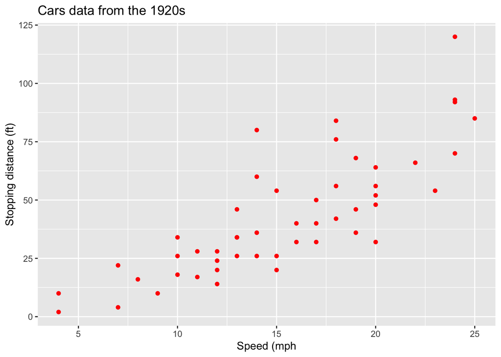

```r
## Type your code here
graph <- ggplot(data = cars, mapping = aes(x = speed, y = dist)) + geom_point(color = "red")
graph <- graph + labs(title = "Cars data from the 1920s", x = "Speed (mph", y = "Stopping distance (ft)")
graph
```

### 5

This line of code reads in the Monona winters dataset assuming you setup your folders in the same way.

```r
## Read Lake Monona data
## Remove rows with missing data
monona = drop_na(read_csv("../../data/lake-monona-winters-2021.csv"))
```

Using this dataset, create a histogram for the `duration` variable showing the distribution of the number of days that the lake is frozen.

Approximately how many winters had between 80 to 100 days where Lake Monona was at least 50% covered with ice?

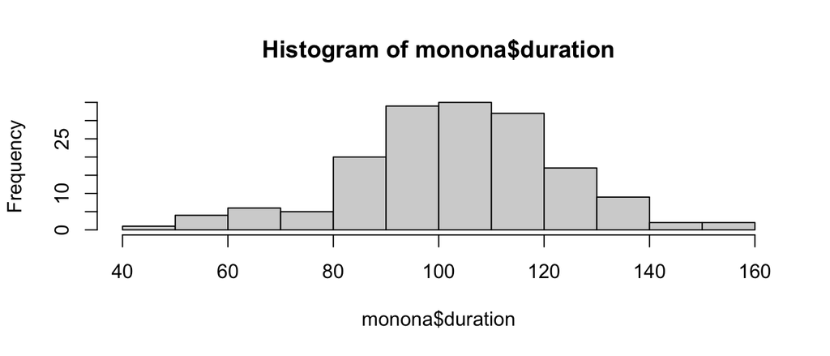

```r
# Type your code here
hist(monona$duration)
```

Approximately 55

### 6

#### 6A

Create a line plot with `duration` on the y axis and `year1` on the x axis. Add a blue smooth curve and a straight red line which estimate the trends. Modify axis labels and add an appropriate title.

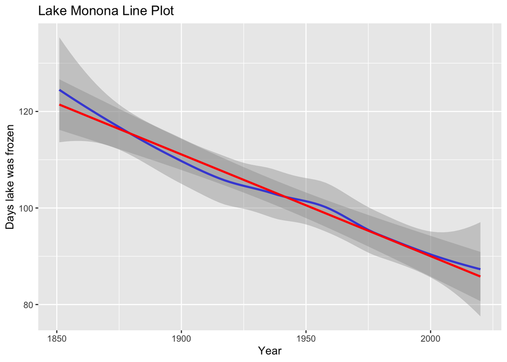

```r
## Type your code here

lineplot <- ggplot(data = monona, mapping = aes(x = year1, y = duration)) + geom_smooth(method=loess, col = "blue") + geom_smooth(method=lm, col='red')
lineplot <- lineplot + labs(title = "Lake Monona Line Plot", x = "Year", y = "Days lake was frozen")
lineplot
```

#### 6B

Compare the curve and the straight line; does the curve differ from the straight line in an important manner?

#### 6C

Looking at your plot, what is the approximate number of days that Lake Monona was closed with ice around 1900?

Approximately 110

#### 6C

Looking at your plot, what is the approximate number of days that Lake Monona was closed with ice around 2000?

Approximately 90